# Supervised Learning - Foundations Project: ReCell

## Exploratory Data Analysis (EDA)

- EDA is an important part of any project involving data.
- It is important to investigate and understand the data better before building a model with it.
- A few questions have been mentioned below which will help you approach the analysis in the right manner and generate insights from the data.
- A thorough analysis of the data, in addition to the questions mentioned below, should be done.

**Questions**:

1. What does the distribution of normalized used device prices look like?
2. What percentage of the used device market is dominated by Android devices?
3. The amount of RAM is important for the smooth functioning of a device. How does the amount of RAM vary with the brand?
4. A large battery often increases a device's weight, making it feel uncomfortable in the hands. How does the weight vary for phones and tablets offering large batteries (more than 4500 mAh)?
5. Bigger screens are desirable for entertainment purposes as they offer a better viewing experience. How many phones and tablets are available across different brands with a screen size larger than 6 inches?
6. A lot of devices nowadays offer great selfie cameras, allowing us to capture our favorite moments with loved ones. What is the distribution of devices offering greater than 8MP selfie cameras across brands?
7. Which attributes are highly correlated with the normalized price of a used device?

## Univariate Analysis

```python
pdeda=pdcell.copy()
```

```python
pdeda.info()
```

```
<class 'pandas.core.frame.DataFrame'>
RangeIndex: 3454 entries, 0 to 3453
Data columns (total 15 columns):
 #   Column                 Non-Null Count  Dtype
---  ------                 --------------  -----
 0   brand_name             3454 non-null   object
 1   os                     3454 non-null   object
 2   screen_size            3454 non-null   float64
 3   4g                     3454 non-null   object
 4   5g                     3454 non-null   object
 5   main_camera_mp         3275 non-null   float64
 6   selfie_camera_mp       3452 non-null   float64
 7   int_memory             3450 non-null   float64
 8   ram                    3450 non-null   float64
 9   battery                3448 non-null   float64
 10  weight                 3447 non-null   float64
 11  release_year           3454 non-null   int64
 12  days_used              3454 non-null   int64
 13  normalized_used_price  3454 non-null   float64
 14  normalized_new_price   3454 non-null   float64
dtypes: float64(9), int64(2), object(4)
memory usage: 404.9+ KB
```

```python
pdeda.describe(include = ['object']).T
```

|  | count | unique | top | freq |
| --- | --- | --- | --- | --- |
| brand_name | 3454 | 34 | Others | 502 |
| os | 3454 | 4 | Android | 3214 |
| 4g | 3454 | 2 | yes | 2335 |
| 5g | 3454 | 2 | no | 3302 |

**1. Visualisation of used devices Brand names**

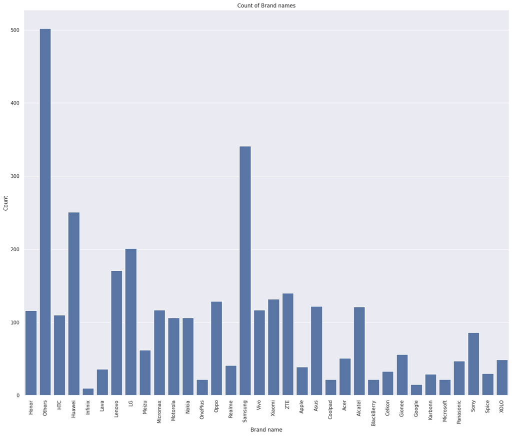

```python
##We visualise the used phones counts for different brands
plt.figure(figsize=(20,16))
sns.countplot(data=pdeda, x='brand_name')
plt.title('Count of Brand names')
plt.xlabel('Brand name')
plt.xticks(rotation=90)
plt.ylabel('Count')
plt.show()
```

1. Samsung, Huawei and LG constitutes most of the brands for used phones.
2. The brands with least devices are Infinix, Google, Microsoft,Blackberry, Coolpad and Oneplus.

**2. Visualistion of the Operating Systems installed on the Used devices**

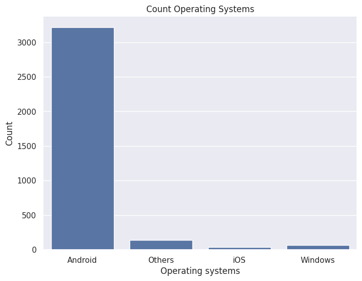

```python
#We visualise the Operating systems installed in the devices
plt.figure(figsize=(8,6))
sns.countplot(data=pdeda, x='os')
plt.title('Count Operating Systems')
plt.xlabel('Operating systems')
plt.ylabel('Count')
plt.show()
```

1. Android operating system dominates the space of devices in the used phones market.

**3. Visualiation of used devices with or without 4G**

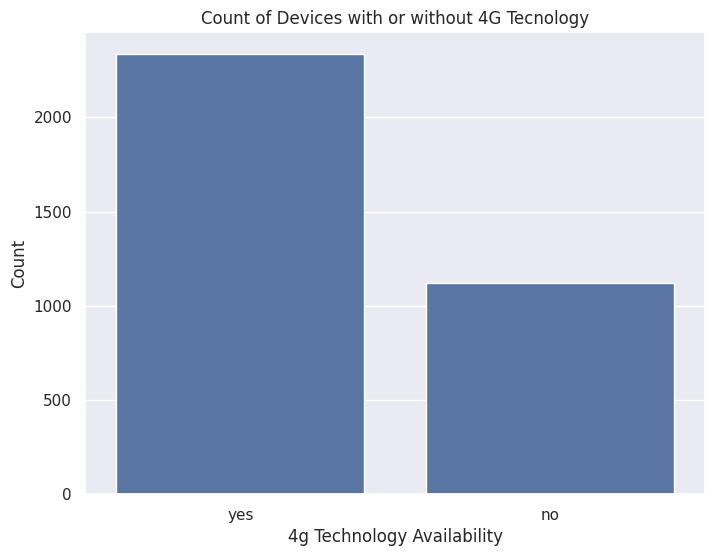

```python
#We visualise the devices with or without 4g technology
plt.figure(figsize=(8,6))
sns.countplot(data=pdeda, x='4g')
plt.title('Count of Devices with or without 4G Tecnology')
plt.xlabel('4g Technology Availability')
plt.ylabel('Count')
plt.show()
```

Most of the devices in the used phones market have 4G technology

**4. Visualiation of used devices with or without 5g**

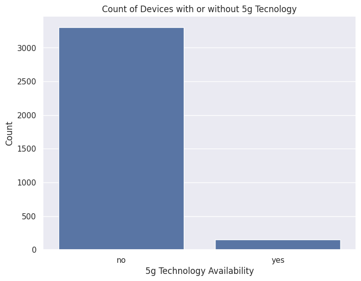

```python
#We visualise the devices with or without 5g technology
plt.figure(figsize=(8,6))
sns.countplot(data=pdeda, x='5g')
plt.title('Count of Devices with or without 5g Tecnology')
plt.xlabel('5g Technology Availability')
plt.ylabel('Count')
plt.show()
```

Very few devices in the used phone market have 5g technology.

**5. Analysis of release year of the device**

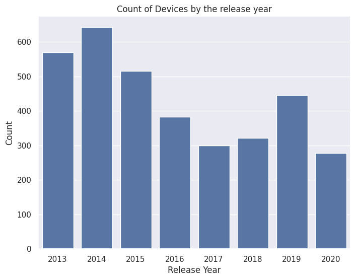

```python
plt.figure(figsize=(8,6))
sns.countplot(data=pdeda, x='release_year')
plt.title('Count of Devices by the release year')
plt.xlabel('Release Year')
plt.ylabel('Count')
plt.show()
```

Most of the devices were released in year 2014, followed by 2013 and 2015 respectively

```python
pdeda.describe(include = ['float64','int64']).T
```

|  | count | mean | std | min | 25% | 50% | 75% | max |
| --- | --- | --- | --- | --- | --- | --- | --- | --- |
| screen_size | 3454.0 | 13.713115 | 3.805280 | 5.080000 | 12.700000 | 12.830000 | 15.340000 | 30.710000 |
| main_camera_mp | 3275.0 | 9.460208 | 4.815461 | 0.080000 | 5.000000 | 8.000000 | 13.000000 | 48.000000 |
| selfie_camera_mp | 3452.0 | 6.554229 | 6.970372 | 0.000000 | 2.000000 | 5.000000 | 8.000000 | 32.000000 |
| int_memory | 3450.0 | 54.573099 | 84.972371 | 0.010000 | 16.000000 | 32.000000 | 64.000000 | 1024.000000 |
| ram | 3450.0 | 4.036122 | 1.365105 | 0.020000 | 4.000000 | 4.000000 | 4.000000 | 12.000000 |
| battery | 3448.0 | 3133.402697 | 1299.682844 | 500.000000 | 2100.000000 | 3000.000000 | 4000.000000 | 9720.000000 |
| weight | 3447.0 | 182.751871 | 88.413228 | 69.000000 | 142.000000 | 160.000000 | 185.000000 | 855.000000 |
| release_year | 3454.0 | 2015.965258 | 2.298455 | 2013.000000 | 2014.000000 | 2015.500000 | 2018.000000 | 2020.000000 |
| days_used | 3454.0 | 674.869716 | 248.580166 | 91.000000 | 533.500000 | 690.500000 | 868.750000 | 1094.000000 |
| normalized_used_price | 3454.0 | 4.364712 | 0.588914 | 1.536867 | 4.033931 | 4.405133 | 4.755700 | 6.619433 |
| normalized_new_price | 3454.0 | 5.233107 | 0.683637 | 2.901422 | 4.790342 | 5.245892 | 5.673718 | 7.847841 |

```python
# function to plot a boxplot and a histogram along the same scale.


def histogram_boxplot(data, feature, figsize=(15, 10), kde=False, bins=None):
    """
    Boxplot and histogram combined

    data: dataframe
    feature: dataframe column
    figsize: size of figure (default (15,10))
    kde: whether to show the density curve (default False)
    bins: number of bins for histogram (default None)
    """
    f2, (ax_box2, ax_hist2) = plt.subplots(
        nrows=2,  # Number of rows of the subplot grid= 2
        sharex=True,  # x-axis will be shared among all subplots
        gridspec_kw={"height_ratios": (0.25, 0.75)},
        figsize=figsize,
    )  # creating the 2 subplots
    sns.boxplot(
        data=data, x=feature, ax=ax_box2, showmeans=True, color="violet"
    )  # boxplot will be created and a triangle will indicate the mean value of the column
    sns.histplot(
        data=data, x=feature, kde=kde, ax=ax_hist2, bins=bins
    ) if bins else sns.histplot(
        data=data, x=feature, kde=kde, ax=ax_hist2
    )  # For histogram
    ax_hist2.axvline(
        data[feature].mean(), color="green", linestyle="--"
    )  # Add mean to the histogram
    ax_hist2.axvline(
        data[feature].median(), color="black", linestyle="-"
    )  # Add median to the histogram
```

```python
# function to create labeled barplots


def labeled_barplot(data, feature, perc=False, n=None):
    """
    Barplot with percentage at the top

    data: dataframe
    feature: dataframe column
    perc: whether to display percentages instead of count (default is False)
    n: displays the top n category levels (default is None, i.e., display all levels)
    """

    total = len(data[feature])  # length of the column
    count = data[feature].nunique()
    if n is None:
        plt.figure(figsize=(count + 2, 6))
    else:
        plt.figure(figsize=(n + 2, 6))

    plt.xticks(rotation=90, fontsize=15)
    ax = sns.countplot(
        data=data,
        x=feature,
        order=data[feature].value_counts().index[:n],
    )

    for p in ax.patches:
        if perc == True:
            label = "{:.1f}%".format(
                100 * p.get_height() / total
            )  # percentage of each class of the category
        else:
            label = p.get_height()  # count of each level of the category

        x = p.get_x() + p.get_width() / 2  # width of the plot
        y = p.get_height()  # height of the plot

        ax.annotate(
            label,
            (x, y),
            ha="center",
            va="center",
            size=12,
            xytext=(0, 5),
            textcoords="offset points",
        )  # annotate the percentage

    plt.show()  # show the plot
```

**1. Device Screen size**

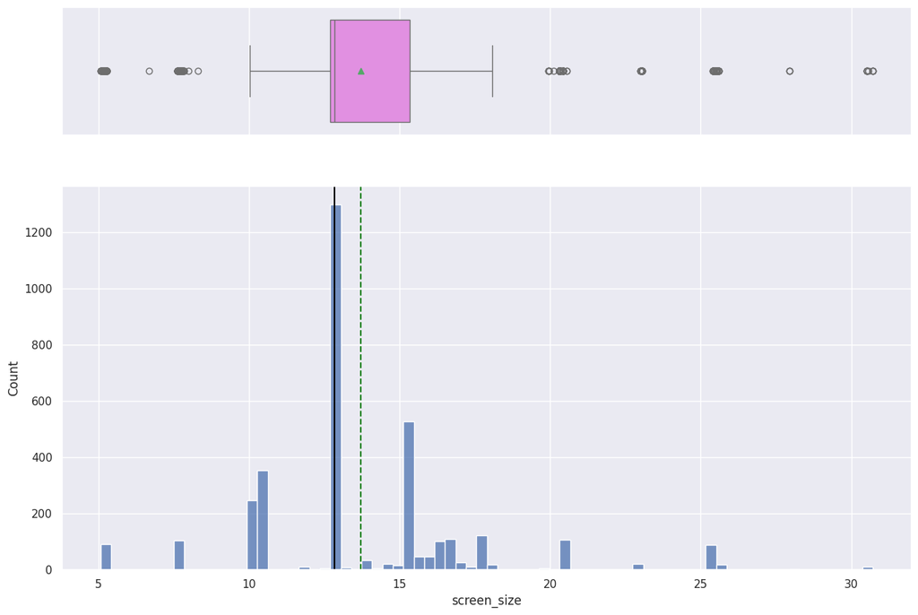

```python
histogram_boxplot(pdeda, "screen_size")
```

**2. Device main camera Megapixels**

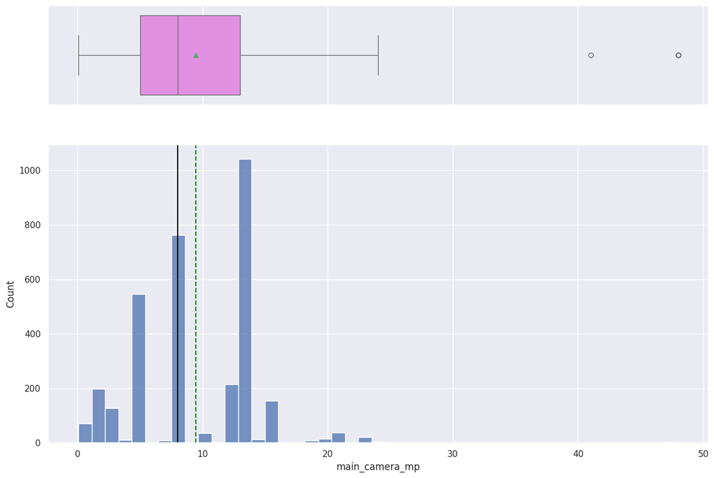

```python
histogram_boxplot(pdeda, "main_camera_mp")
```

1. The distributions is right skewed
2. Outliers to the right indicate very high resolution cameras
3. The mean megapixels (MP) for the main camera is 9 MP

**3. Device selfie camera Megapixels**

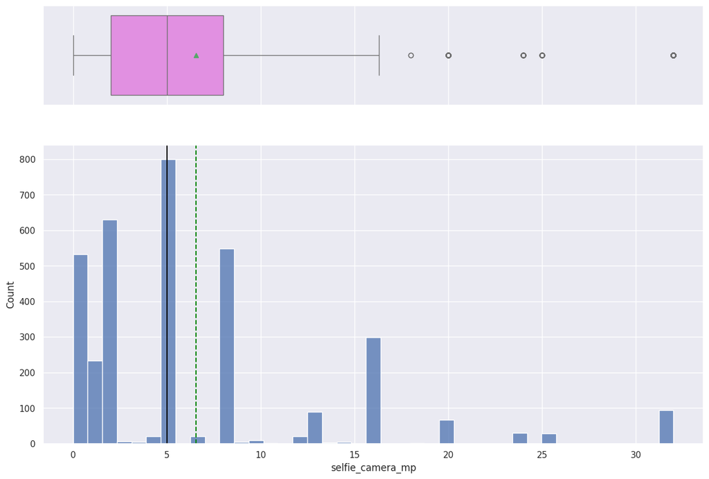

```python
histogram_boxplot(pdeda, "selfie_camera_mp")
```

1. The distributions is right skewed
2. Outliers to the right indicate very high resolution cameras
3. The mean megapixels (MP) for the selfie camera is 6 MP
4. The dominant resolution is 5mp with 800 devices

**4. Device random-access memory (RAM) analysis**

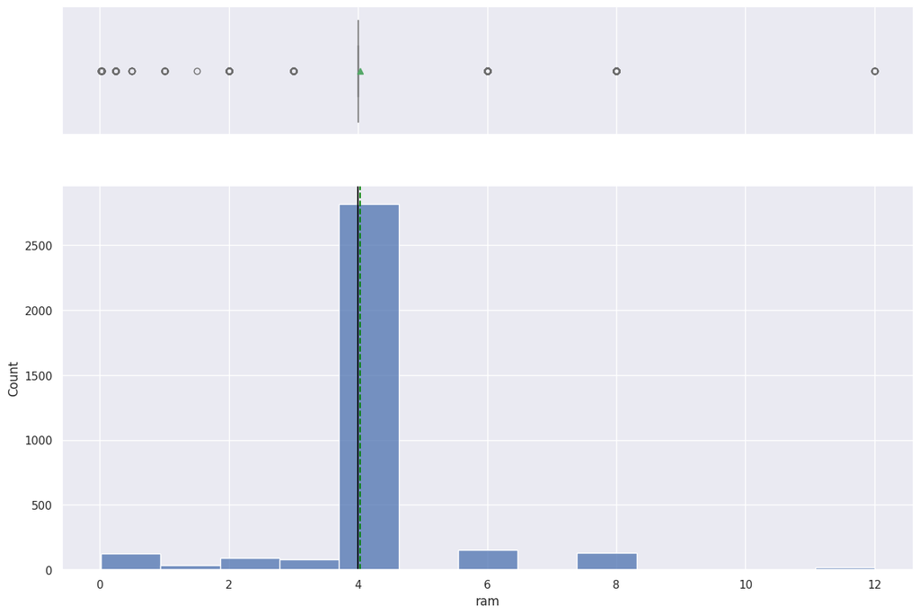

```python
histogram_boxplot(pdeda, "ram")
```

1. Distributions are right skewed
2. Outliers to the right indicate phones with very large amounts random access memory (RAM)
3. Outliers to the left indicate phones with very small amounts random access memory (RAM)
4. The mean amounts of RAM is 4GB

**5. Device internal memory (int_memory) analysis**

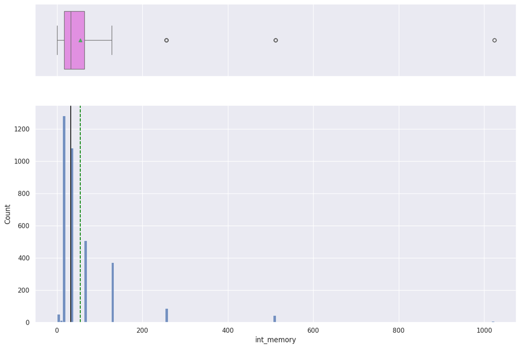

```python
histogram_boxplot(pdeda, "int_memory")
```

**6. Analysis of Battery Energy capacity of the device battery in mAh**

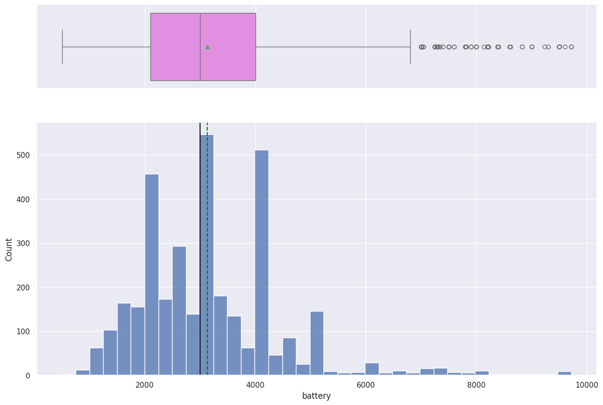

```python
histogram_boxplot(pdeda, "battery")
```

1. The distribution is right skewed
2. There are many outliers to the right indicating phones with very large batteries capacity
3. The mean battery capacity is 3133.402697

**7. Analysis of Weight of the device in grams**

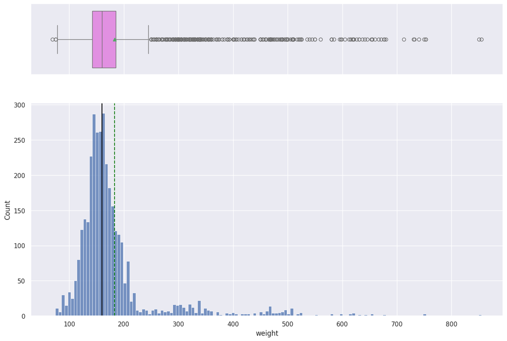

```python
histogram_boxplot(pdeda, "weight")
```

1. Distribution is heavily right skewed
2. Outliers to the right indicate very heavy phones (~450g = 1 lb)
3. The mean weight is 182.751871

**8. Analysis of days used of the device**

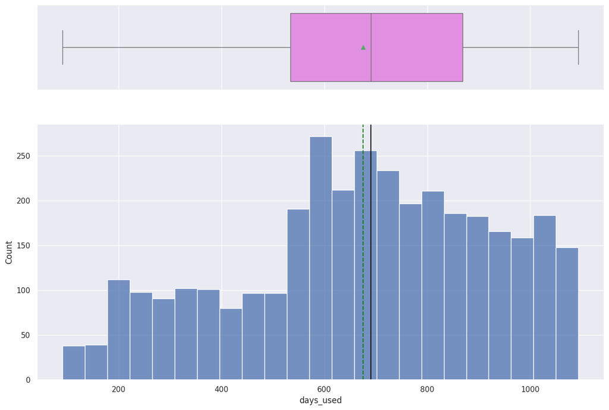

```python
histogram_boxplot(pdeda, "days_used")
```

```python
pdeda.describe(include = ['int64']).T
```

|  | count | mean | std | min | 25% | 50% | 75% | max |
| --- | --- | --- | --- | --- | --- | --- | --- | --- |
| release_year | 3454.0 | 2015.965258 | 2.298455 | 2013.0 | 2014.0 | 2015.5 | 2018.00 | 2020.0 |
| days_used | 3454.0 | 674.869716 | 248.580166 | 91.0 | 533.5 | 690.5 | 868.75 | 1094.0 |

**9. Analysis of Normalised used price of the device**

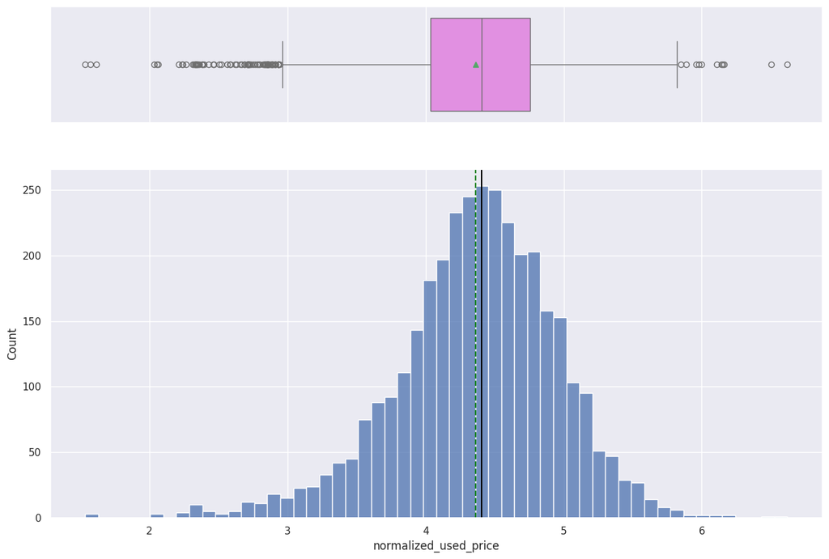

```python
histogram_boxplot(pdeda, "normalized_used_price")
```

```python
pdeda.normalized_used_price.describe().T
```

```
count    3454.000000
mean        4.364712
std         0.588914
min         1.536867
25%         4.033931
50%         4.405133
75%         4.755700
max         6.619433
Name: normalized_used_price, dtype: float64
```

1. The normalized used price of used phones approximately follows a normal distribution. The mean is very close to the 50th percentile denoting normal distribution.
2. From the box_plot we can see that there are outliers both on the left and the right suggesting extremely low prices and extremely high prices for used phones.
3. The normalised used price for the first 50% of the devices is between 1.5 and 4.4

**10. Analysis of the Normalized new price of a new device of the same model in euros**

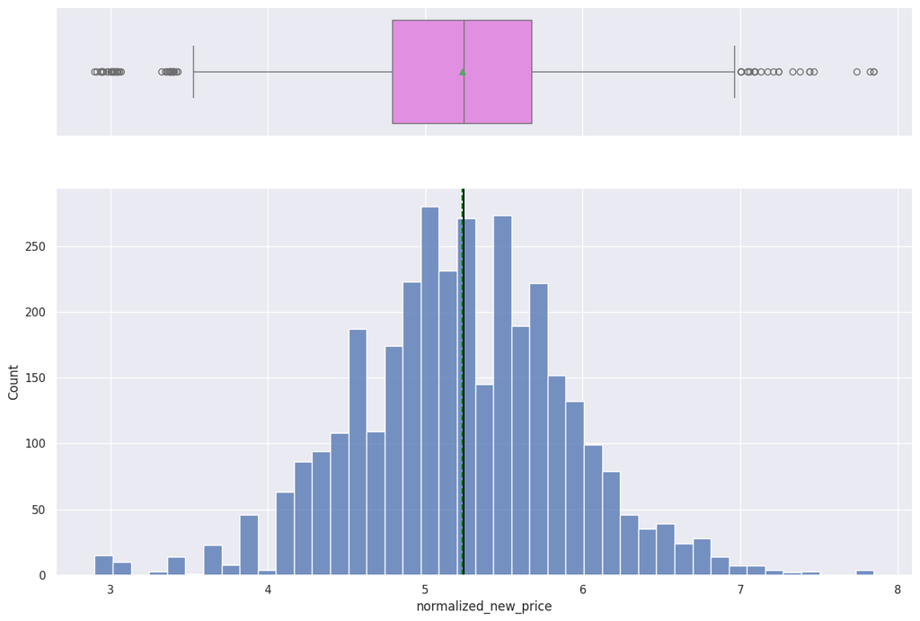

```python
histogram_boxplot(pdeda, "normalized_new_price")
```

```python
pdeda.normalized_new_price.describe().T
```

```
count    3454.000000
mean        5.233107
std         0.683637
min         2.901422
25%         4.790342
50%         5.245892
75%         5.673718
max         7.847841
Name: normalized_new_price, dtype: float64
```

1. The price is approximately normally distributed. The mean and the median are very close (5.233107 and 5.245892) respectively.
2. There are outliers on the left and the right indicating extreme prices for a new device in the market

## **Answering the Questions Raised Above**

### **1. What does the distribution of normalized used device prices look like?**

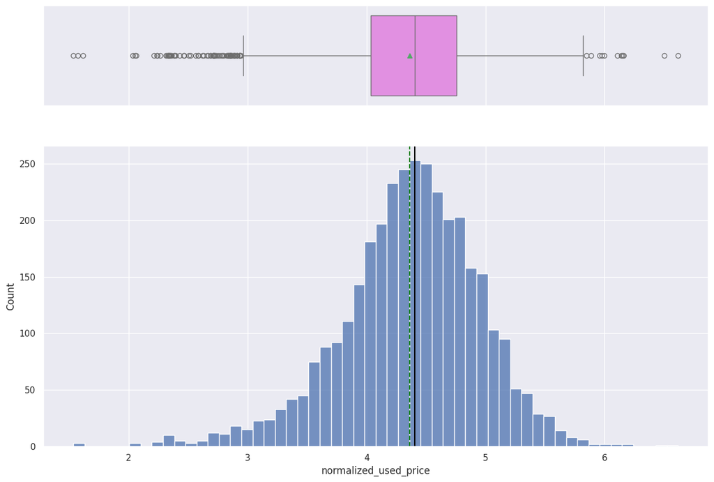

```python
#We visualise the normalised used price
histogram_boxplot(pdeda, "normalized_used_price")
```

```python
##Get a statistical summary of normalized_used_price
pdeda.normalized_used_price.describe().T
```

```
count    3454.000000
mean        4.364712
std         0.588914
min         1.536867
25%         4.033931
50%         4.405133
75%         4.755700
max         6.619433
Name: normalized_used_price, dtype: float64
```

The distribution of normalized used device prices is approximately normal.

### **2. What percentage of the used device market is dominated by Android devices?**

```python
##We establish the count of Operating systems for different devices
pdeda.os.value_counts()
```

```
os
Android    3214
Others      137
Windows      67
iOS          36
Name: count, dtype: int64
```

```python
##We compute the percentages
pdeda['os'].value_counts(normalize=True)*100
```

```
os
Android    93.051534
Others      3.966416
Windows     1.939780
iOS         1.042270
Name: proportion, dtype: float64
```

Androind is installed in 93% of the devices in the used devices market.

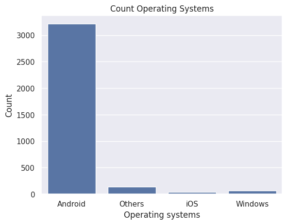

```python
#We visualise the operating systems for the used devices
sns.countplot(data=pdeda, x='os')
plt.title('Count Operating Systems')
plt.xlabel('Operating systems')
plt.ylabel('Count')
plt.show()
```

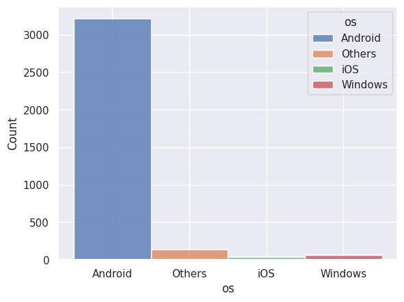

```python
sns.histplot(data=pdeda, x="os", hue="os", multiple="stack")
plt.show()
```

1. The "Android" phones dominate the market

```python
##We establish the counts of RAM for the devices
pdeda.ram.value_counts()
```

```
ram
4.00     2815
6.00      154
8.00      130
2.00       90
0.25       83
3.00       81
1.00       34
12.00      18
0.02       18
0.03       17
0.50        9
1.50        1
Name: count, dtype: int64
```

```python
##We compute the percentages
pdeda.ram.value_counts(normalize=True)*100
```

```
ram
4.00     81.594203
6.00      4.463768
8.00      3.768116
2.00      2.608696
0.25      2.405797
3.00      2.347826
1.00      0.985507
12.00     0.521739
0.02      0.521739
0.03      0.492754
0.50      0.260870
1.50      0.028986
Name: proportion, dtype: float64
```

1. 81% of the devices in the used phone market have 4GB RAM

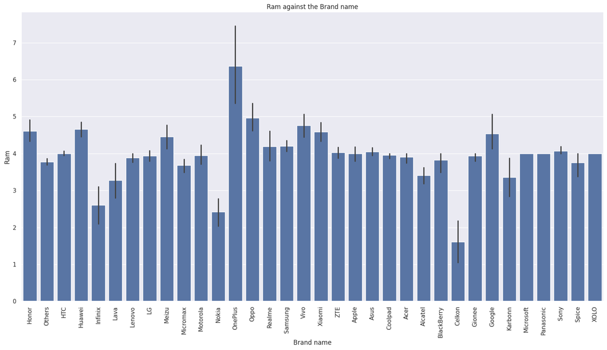

```python
#We visualise Ram against the Brand name
plt.figure(figsize=(20, 10))
sns.barplot(x="brand_name", y="ram", data=pdeda)
plt.xticks(rotation=90);
plt.title('Ram against the Brand name')
plt.xlabel('Brand name')
plt.ylabel('Ram')
plt.show()
```

Onplus gives more RAM. Other brands that have more RAM are Google,Oppo,Honor, Huaweii, Meizu, Vivo and Xiaomi

```python
pdeda.ram.value_counts()
```

```
ram
4.00     2815
6.00      154
8.00      130
2.00       90
0.25       83
3.00       81
1.00       34
12.00      18
0.02       18
0.03       17
0.50        9
1.50        1
Name: count, dtype: int64
```

1. The RAM size is distributed in all Brands but its clear that a RAM of 4GB is available in most of the Brands.
2. Very few phones across all brands have RAM of more than 8GB.

### **4. A large battery often increases a device's weight, making it feel uncomfortable in the hands. How does the weight vary for phones and tablets offering large batteries (more than 4500 mAh)?**

```python
# brand name vs battery
pd_large_battery = pdeda[pdeda.battery > 4500]
pd_large_battery.shape
```

```
(341, 15)
```

There are 341 devices with battery larger than 4500mAh

```python
pd_large_battery.brand_name.value_counts()
```

```
brand_name
Samsung      50
Others       41
Huawei       37
Xiaomi       31
Lenovo       28
Asus         22
Apple        17
Honor        14
Motorola     14
Vivo         13
LG           12
Realme       12
Gionee       10
ZTE          10
Acer          7
Infinix       6
Sony          6
Oppo          4
Alcatel       1
Google        1
HTC           1
Micromax      1
Nokia         1
Panasonic     1
Spice         1
Name: count, dtype: int64
```

Samsung offers most phones with large batteries together with Huawei and Xiaomi.

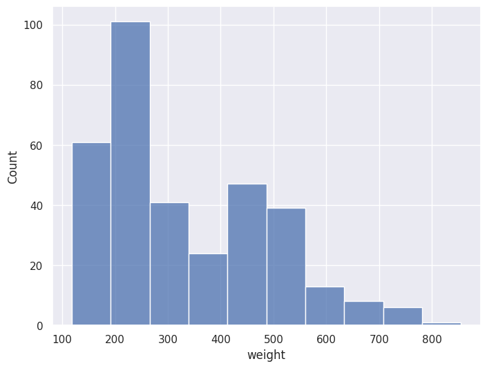

```python
plt.figure(figsize=(8,6))
sns.histplot(data=pd_large_battery, x="weight")
plt.show()
```

Most phones with large batteries have a weight of 200.

### **5. Bigger screens are desirable for entertainment purposes as they offer a better viewing experience. How many phones and tablets are available across different brands with a screen size larger than 6 inches?**

[figure not shown]

```python
plt.figure(figsize=(20, 10))
sns.barplot(x="brand_name", y="screen_size", data=pdeda)
plt.xticks(rotation=90);
plt.title('Screen size against the Brand names')
plt.xlabel('Brand name')
plt.ylabel('Screen Size')
plt.show()
```

Apple generally offers bigger screen sizes

```python
#We filter screen sizes bigger than 6 inches
pd_large_screen = pdeda[pdeda.screen_size > 6]
pd_large_screen.shape
```

```
(3362, 15)
```

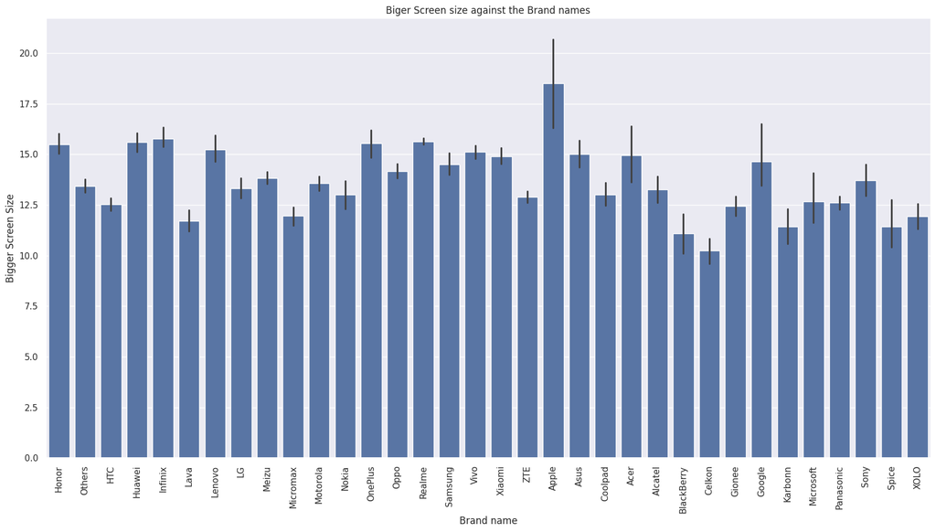

```python
#We visualise how different large screen sizes are distributed across different brands

plt.figure(figsize=(20, 10))
sns.barplot(x="brand_name", y="screen_size", data=pd_large_screen)
plt.xticks(rotation=90);
plt.title('Biger Screen size against the Brand names')
plt.xlabel('Brand name')
plt.ylabel('Bigger Screen Size')
plt.show()
```

Apple leads the phones with bigger screen sizes

```python
pd_large_screen.brand_name.value_counts()
```

```
brand_name
Others        479
Samsung       334
Huawei        251
LG            197
Lenovo        171
ZTE           140
Xiaomi        132
Oppo          129
Asus          122
Vivo          117
Honor         116
Alcatel       115
HTC           110
Micromax      108
Motorola      106
Sony           86
Nokia          72
Meizu          62
Gionee         56
Acer           51
XOLO           49
Panasonic      47
Realme         41
Apple          39
Lava           36
Spice          30
Karbonn        29
Celkon         25
Coolpad        22
OnePlus        22
Microsoft      22
BlackBerry     21
Google         15
Infinix        10
Name: count, dtype: int64
```